# Exploratory Data Analysis

MSDS 6372: Jacob Turner

Isabella Westlauer

2026-11-15

# Relationships between Predictors and Target Variable and Among Predictors

The following analysis explores the relationships between the predictors and the target variable, as well as the relationships among the predictors themselves. This will help identify potential multicollinearity issues and inform feature selection for predictive modeling.

## Ingest

```r
library(tidyverse)
# library(ggplot2)
# library(dplyr)
# library(tidyr)
library(scales)
library(car) # for variance inflation factor (VIF) calculation

# Apply custom theme to all ggplots
source("project_theme.R")
theme_set(theme_bank())

bank_add <- read.csv("../Data/bank-additional-full.csv", sep = ";")
# bank_full <- read.csv("../Data/bank-full.csv", sep = ";")
```

## Tables of Categorical Predictors vs Target Variable

```r
# Identify categorical predictors
cat_vars <- bank_add %>%
  select(where(~ is.factor(.) | is.character(.))) %>%
  select(-any_of("y")) %>%
  names()

# Create a contingency table for each categorical predictor and the target variable
for (var in cat_vars) {
  print(table(bank_add[[var]], bank_add$y))
}
```

```
##
##                   no  yes
##   admin.        9070 1352
##   blue-collar   8616  638
##   entrepreneur  1332  124
##   housemaid      954  106
##   management    2596  328
##   retired       1286  434
##   self-employed 1272  149
##   services      3646  323
##   student        600  275
##   technician    6013  730
##   unemployed     870  144
##   unknown        293   37
##
##               no   yes
##   divorced  4136   476
##   married  22396  2532
##   single    9948  1620
##   unknown     68    12
##
##                          no   yes
##   basic.4y             3748   428
##   basic.6y             2104   188
##   basic.9y             5572   473
##   high.school          8484  1031
##   illiterate             14     4
##   professional.course  4648   595
##   university.degree   10498  1670
##   unknown              1480   251
##
##              no   yes
##   no      28391  4197
##   unknown  8154   443
##   yes         3     0
##
##              no   yes
##   no      16596  2026
##   unknown   883   107
##   yes     19069  2507
```

[output cut: 18 more lines]

```
##   nov  3685   416
##   oct   403   315
##   sep   314   256
##
##         no  yes
##   fri 6981  846
##   mon 7667  847
##   thu 7578 1045
##   tue 7137  953
##   wed 7185  949
##
##                  no   yes
##   failure      3647   605
##   nonexistent 32422  3141
##   success       479   894
```

## Plots of Categorical Predictors vs Target Variable

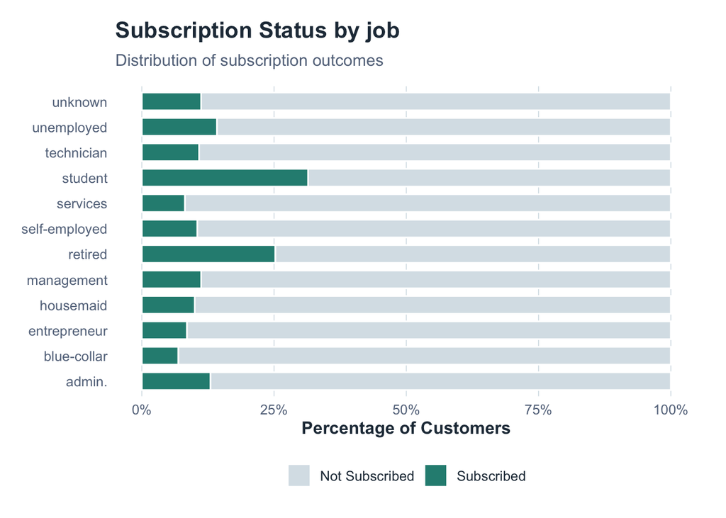

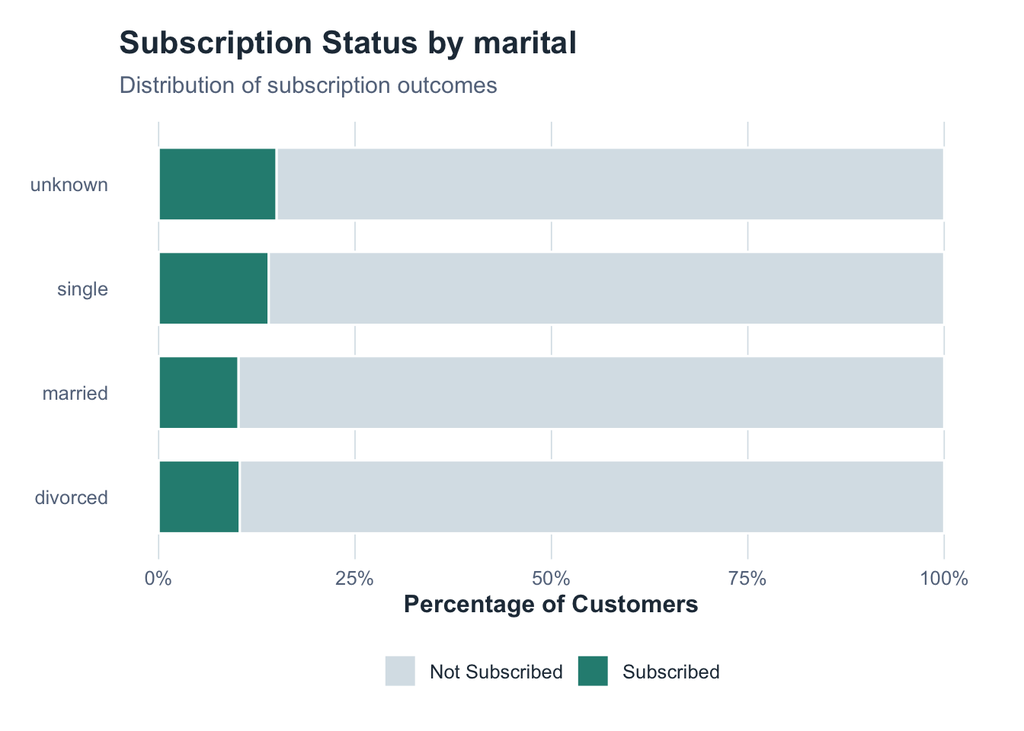

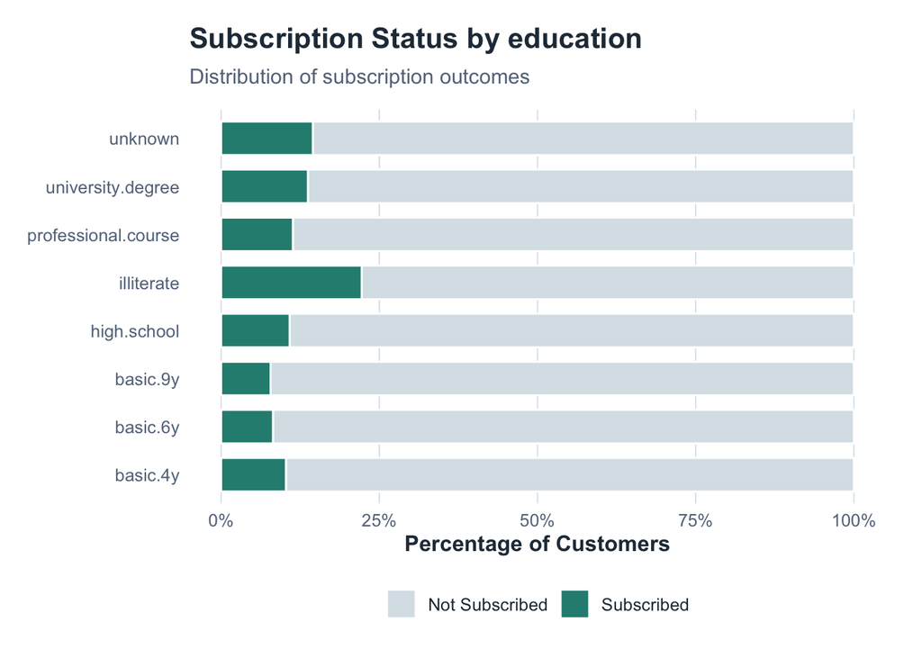

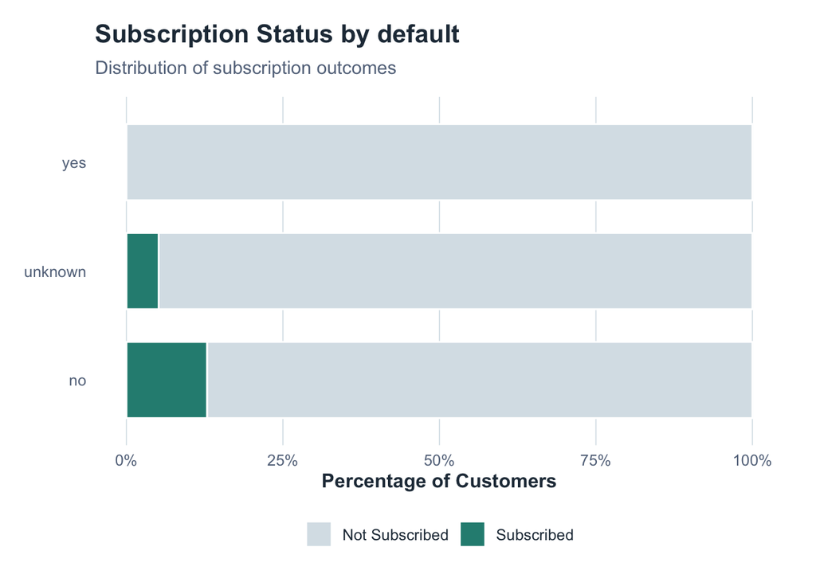

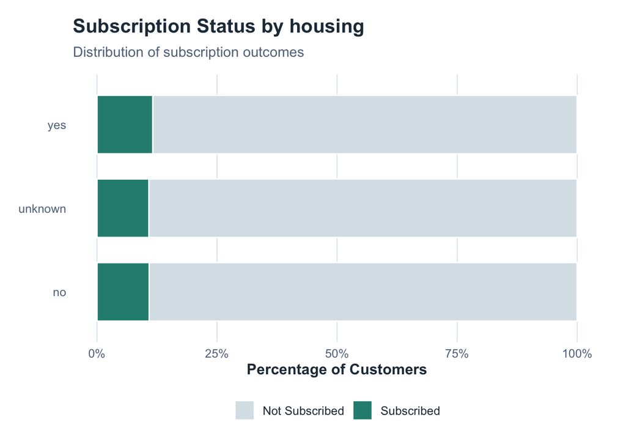

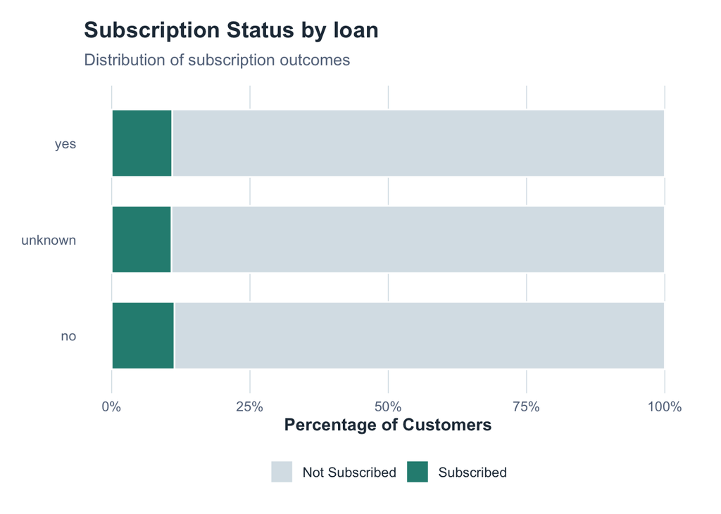

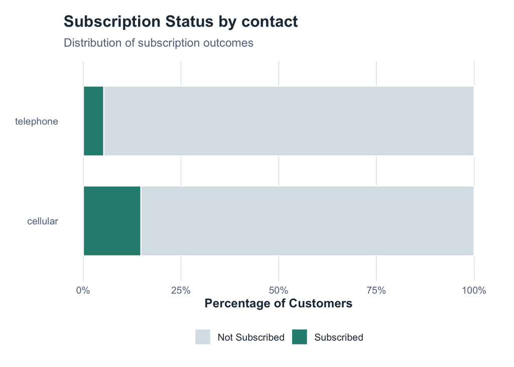

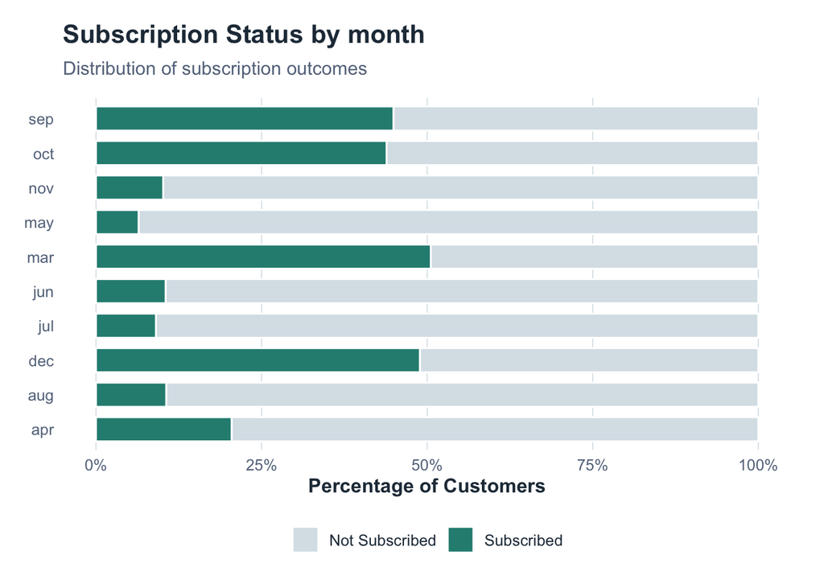

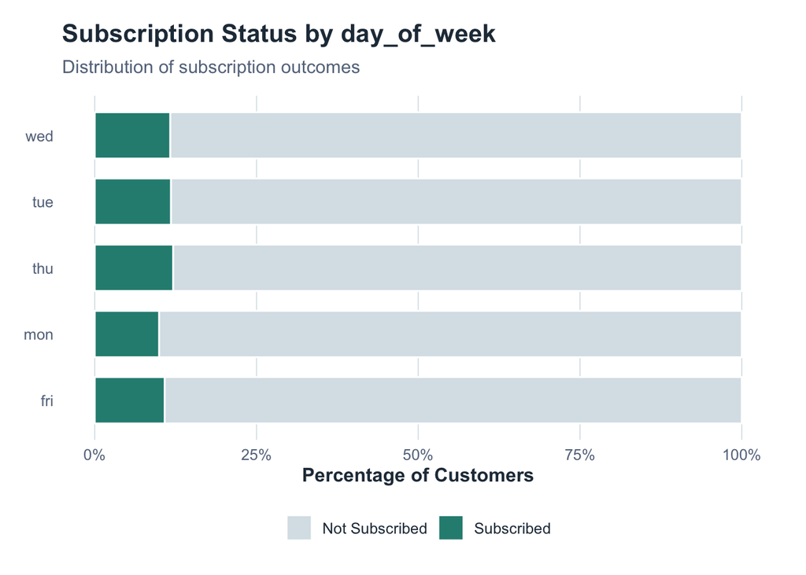

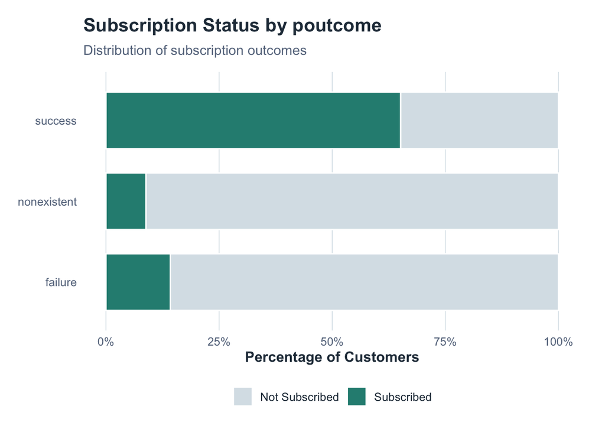

```r
# make sure the months are in order
month_levels <- c(
  "jan", "feb", "mar", "apr", "may", "jun",
  "jul", "aug", "sep", "oct", "nov", "dec"
)

for (var in cat_vars) {

  p <- ggplot(
    bank_add,
    aes(x = .data[[var]], fill = y)
  ) +
    geom_bar(
      position = "fill",
      width = 0.7,
      color = "white"
    ) +
    scale_fill_manual(
      values = subscription_colors,
      labels = c(
        "no" = "Not Subscribed",
        "yes" = "Subscribed"
      ),
      name = NULL
    ) +
    scale_y_continuous(
      labels = percent_format()
    ) +
    coord_flip() +
    labs(
      title = paste("Subscription Status by", var),
      subtitle = "Distribution of subscription outcomes",
      x = NULL,
      y = "Percentage of Customers"
    ) +
    theme(
      panel.grid.major.y = element_blank()
    )

  print(p)
}
```

## GLM Plots of Numerical Predictors vs Target Variable

These plots show the relationship between each numerical predictor and the probability of subscription. The logistic regression curve (in coral) provides a parametric fit, while the jittered points show the distribution of subscription outcomes for each predictor value.

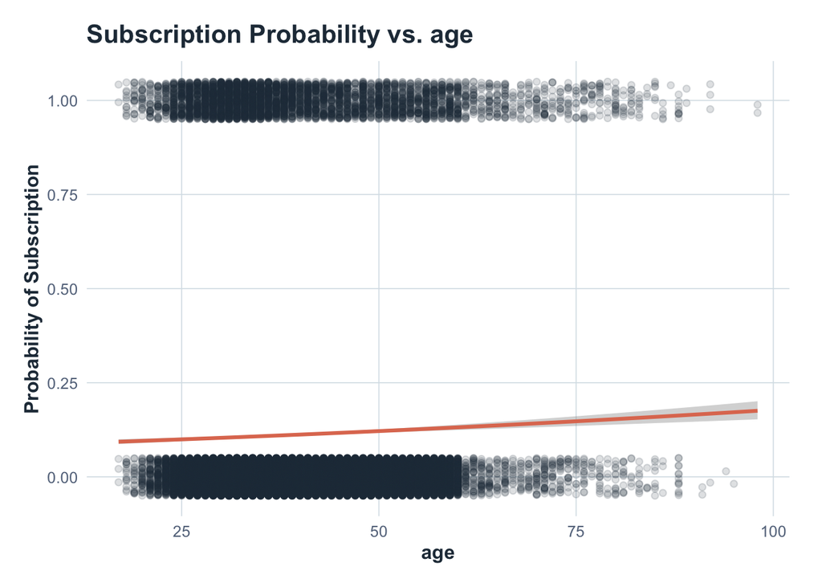

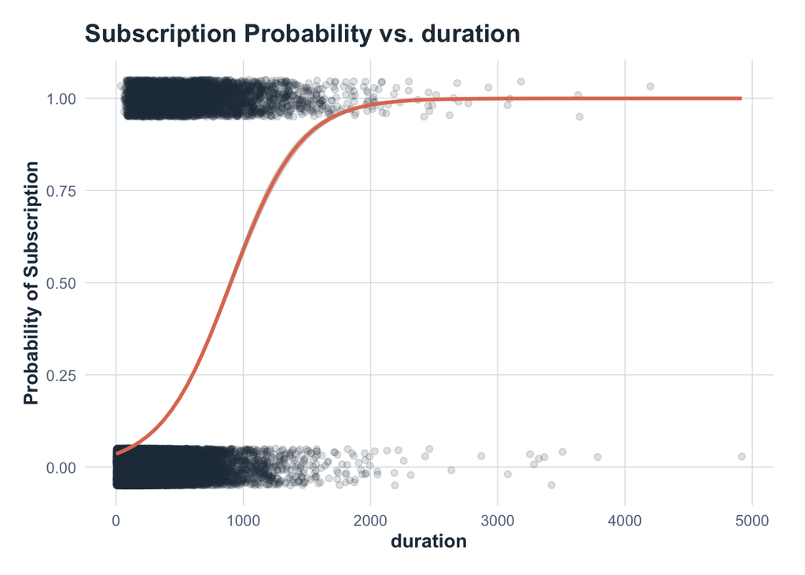

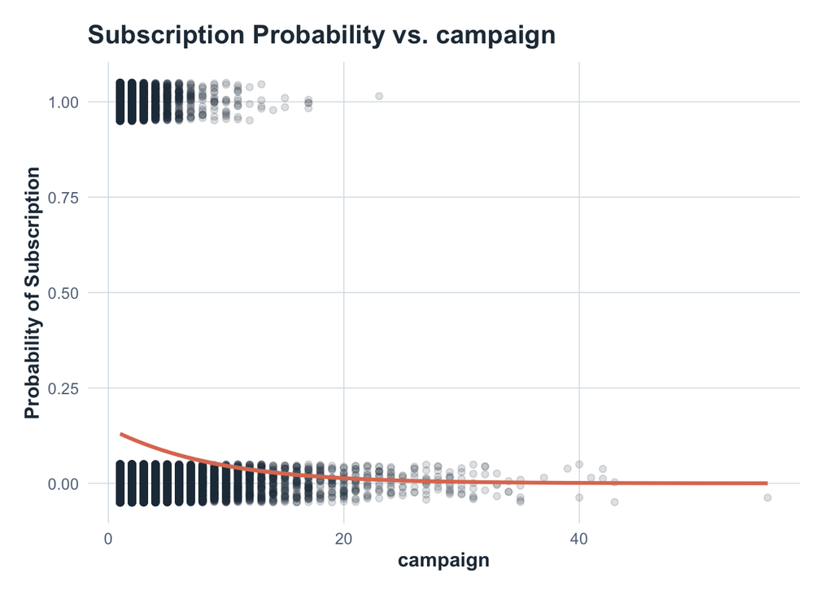

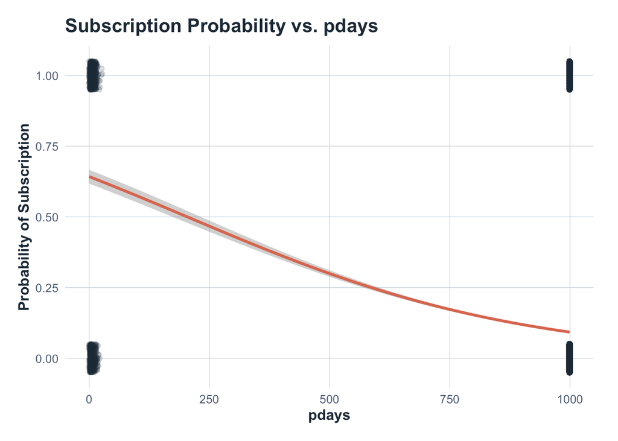

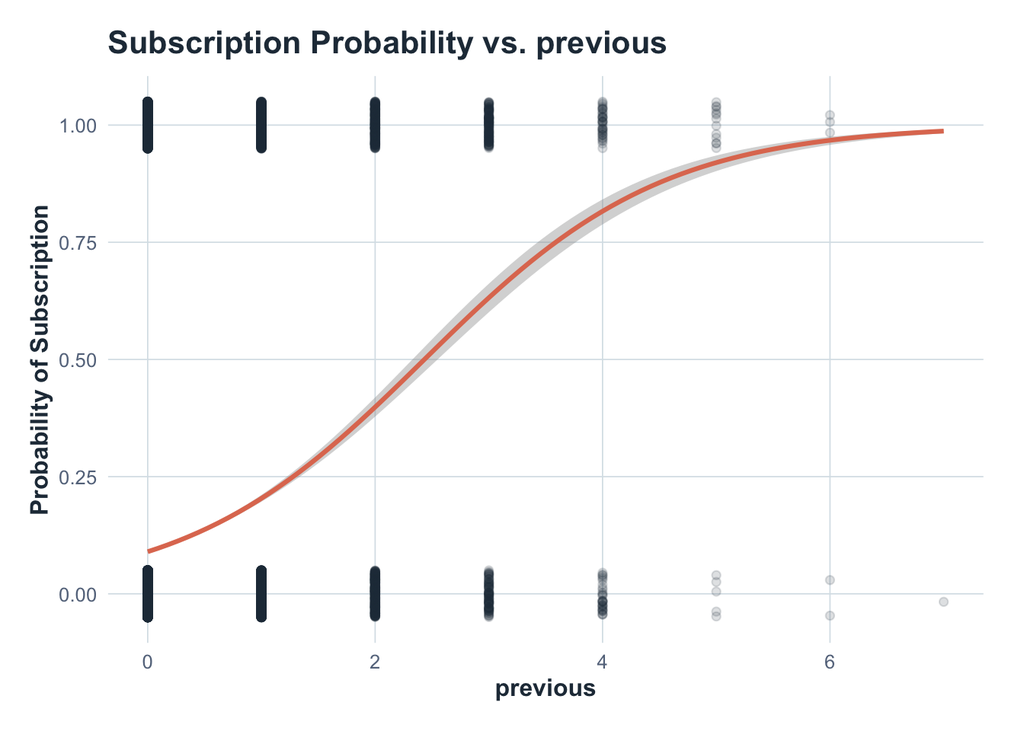

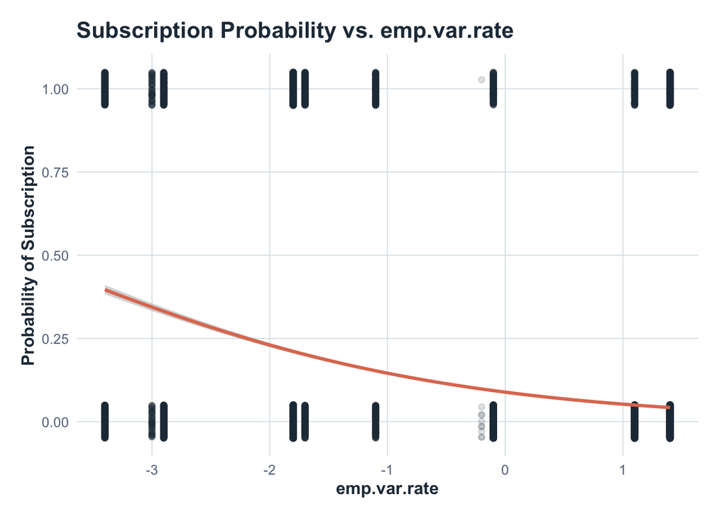

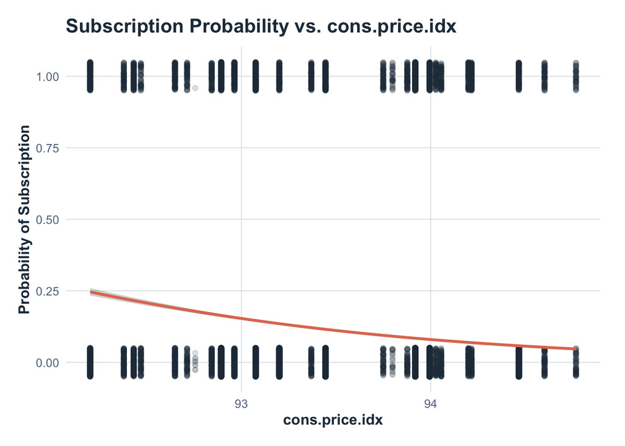

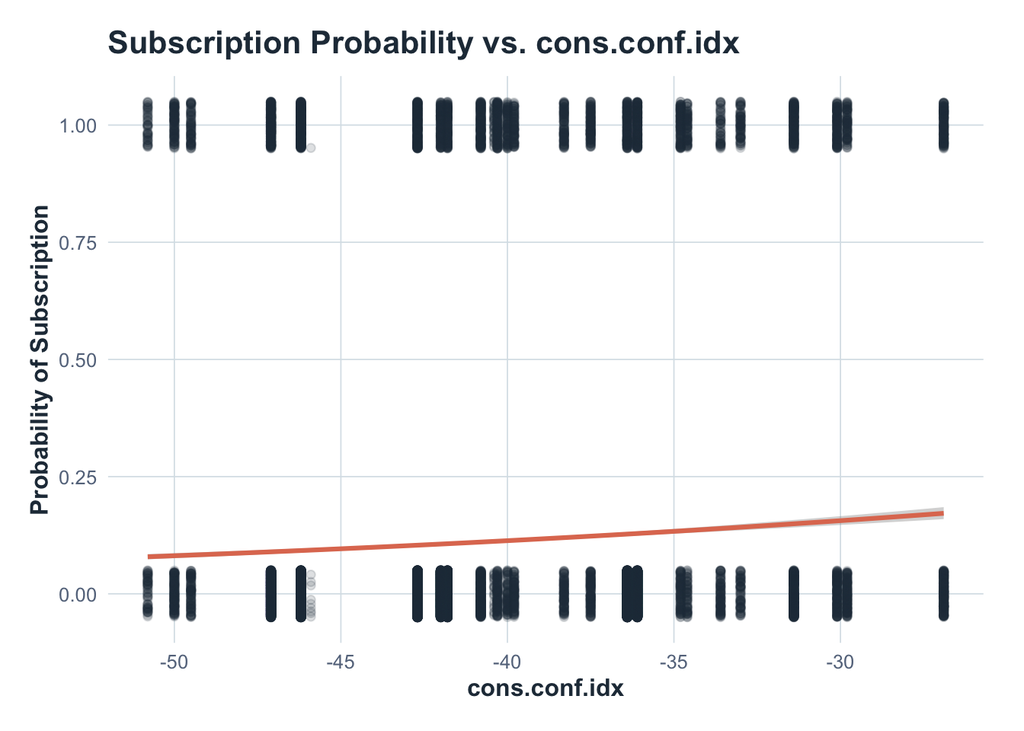

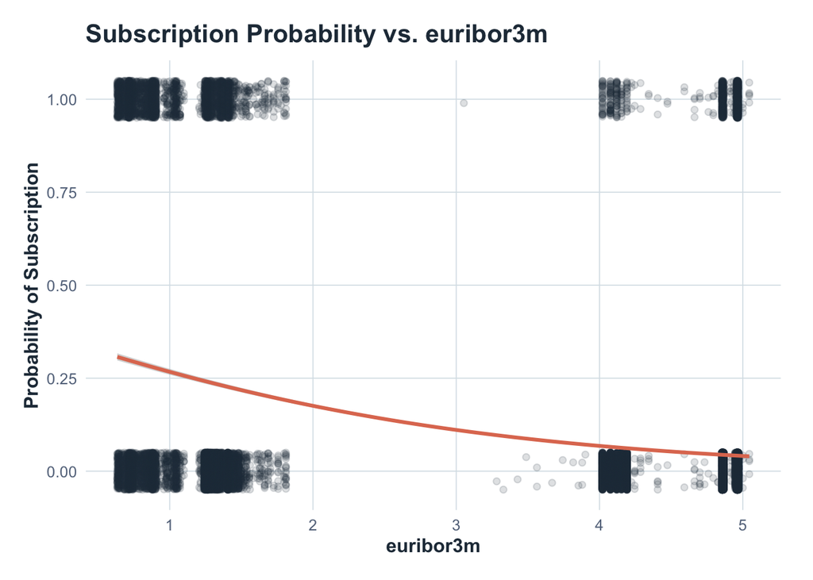

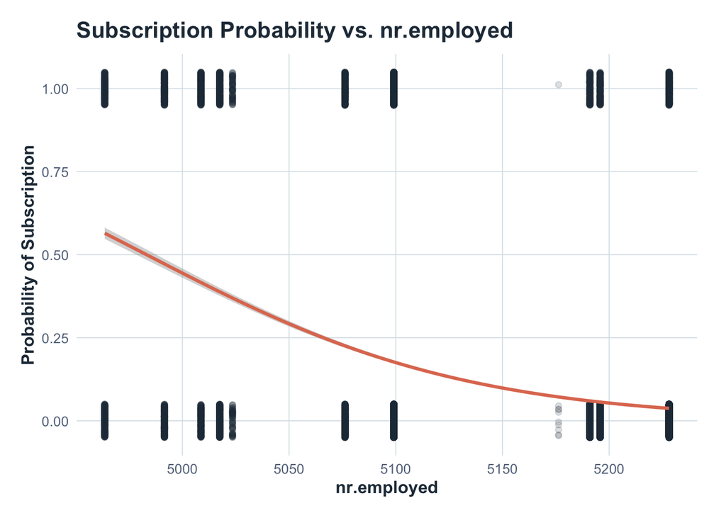

```r
# Identify numerical predictors
num_vars <- bank_add %>%
  select(where(is.numeric)) %>%
  names()

# Binary response for plotting
bank_add <- bank_add %>%
  mutate(y_num = as.integer(y == "yes"))

for (var in num_vars) {
  p <- ggplot(bank_add,
              aes(x = .data[[var]], y = y_num)) +
    geom_jitter(
      height = 0.05,
      width = 0,
      alpha = 0.15,
        color = bank_colors["slate"]
    ) +
    geom_smooth(
      method = "glm",
      method.args = list(family = "binomial"),
      se = TRUE,
      color = bank_colors["coral"]
    ) +
    labs(
      title = paste("Subscription Probability vs.", var),
      x = var,
      y = "Probability of Subscription"
    ) +
    theme_bank()

  print(p)
}
```

## Compare Loess and Logistic Regression Fits

The loess curve helps us discover potential non-linear relationships between the numerical predictors and the target variable. The logistic regression curve provides a parametric fit that can be used for prediction. By comparing these two curves, we can assess whether a linear model is appropriate or if a more flexible model may be needed.

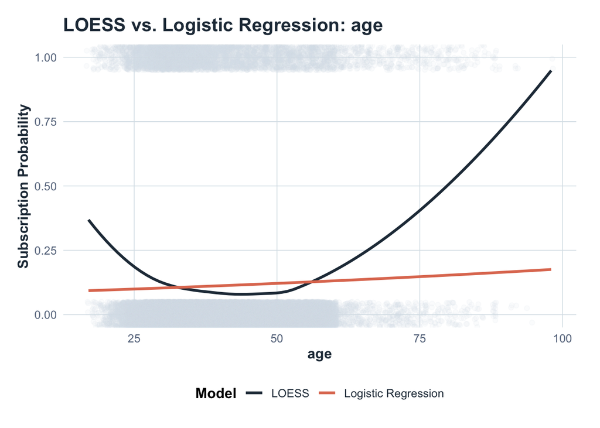

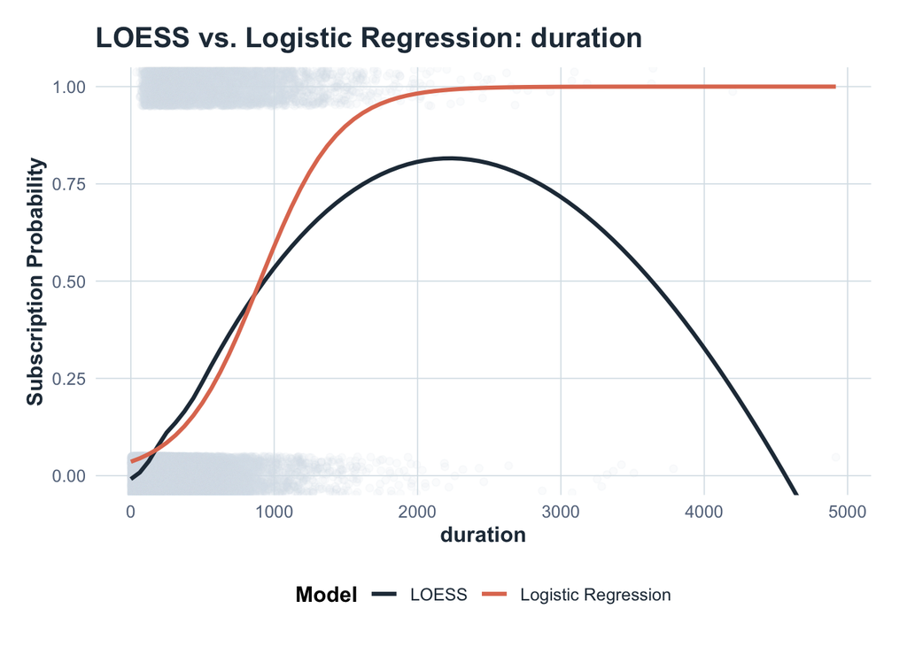

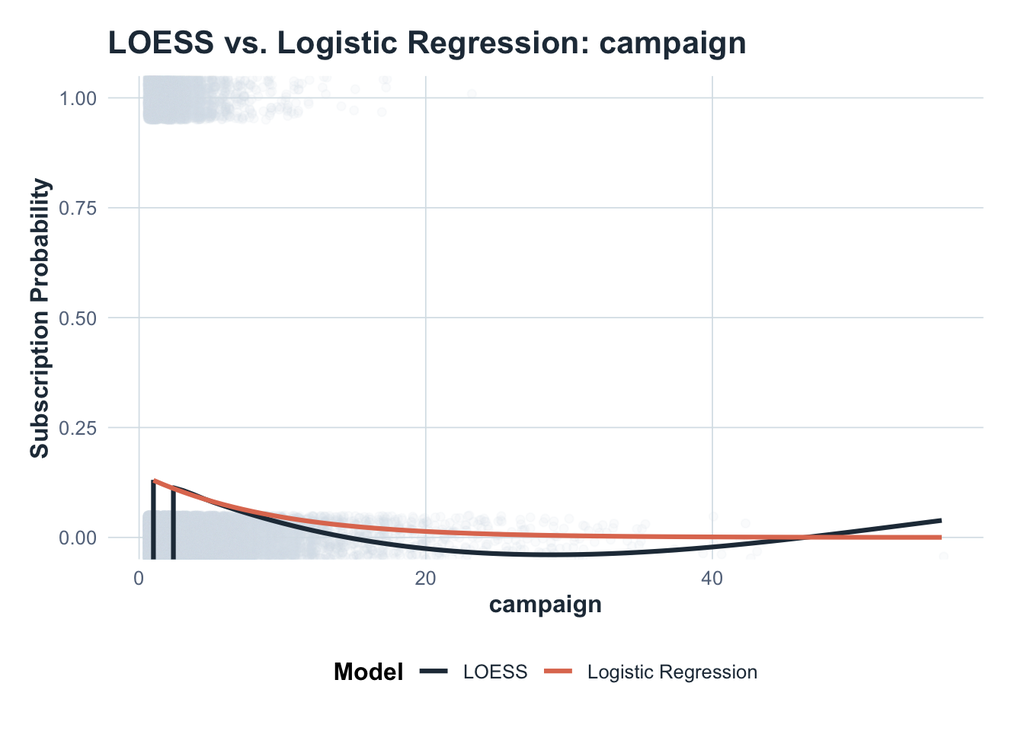

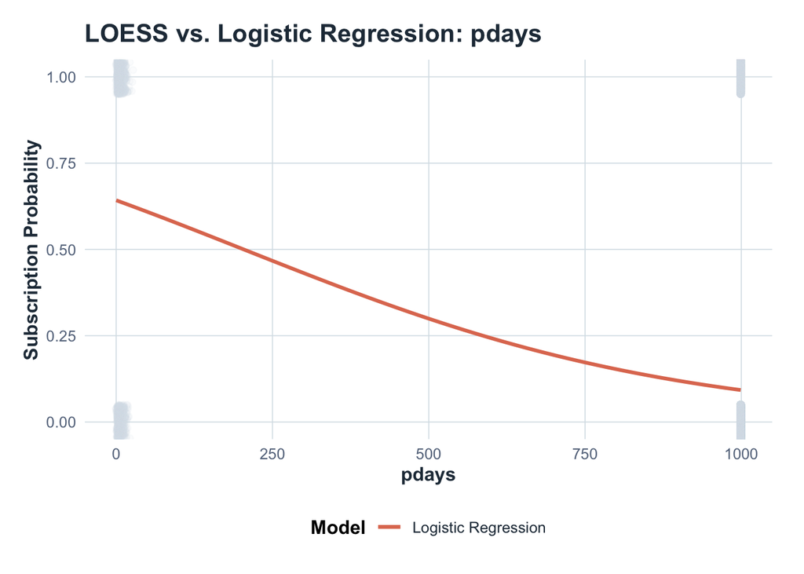

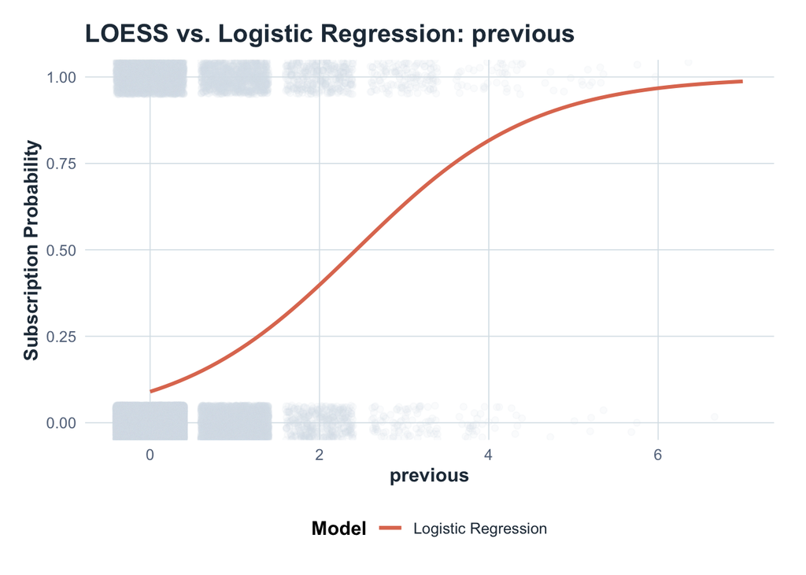

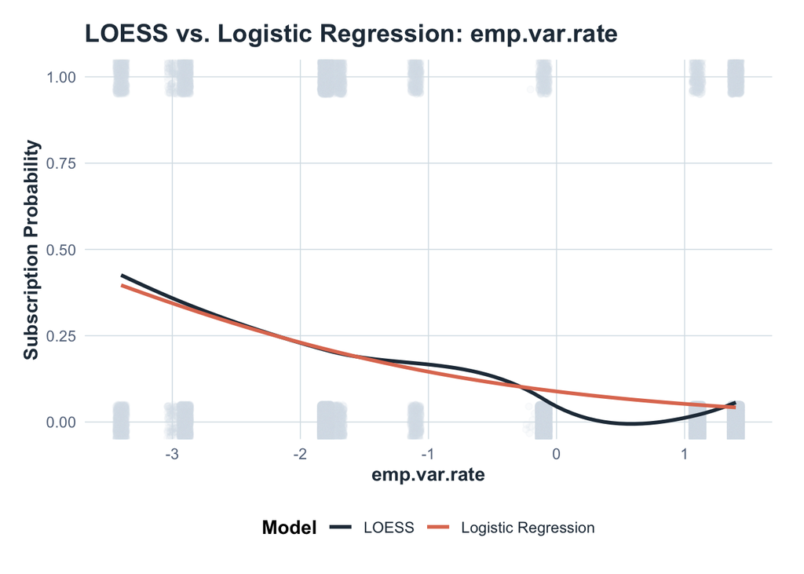

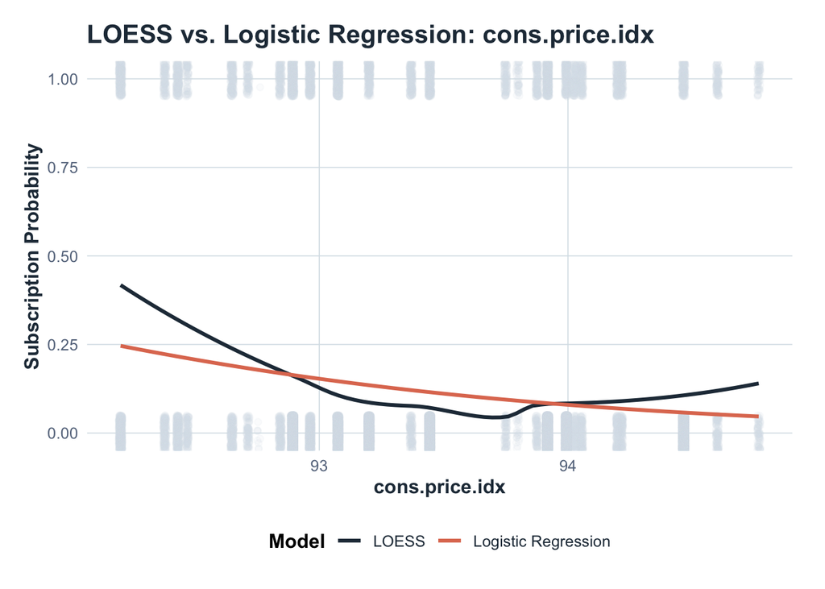

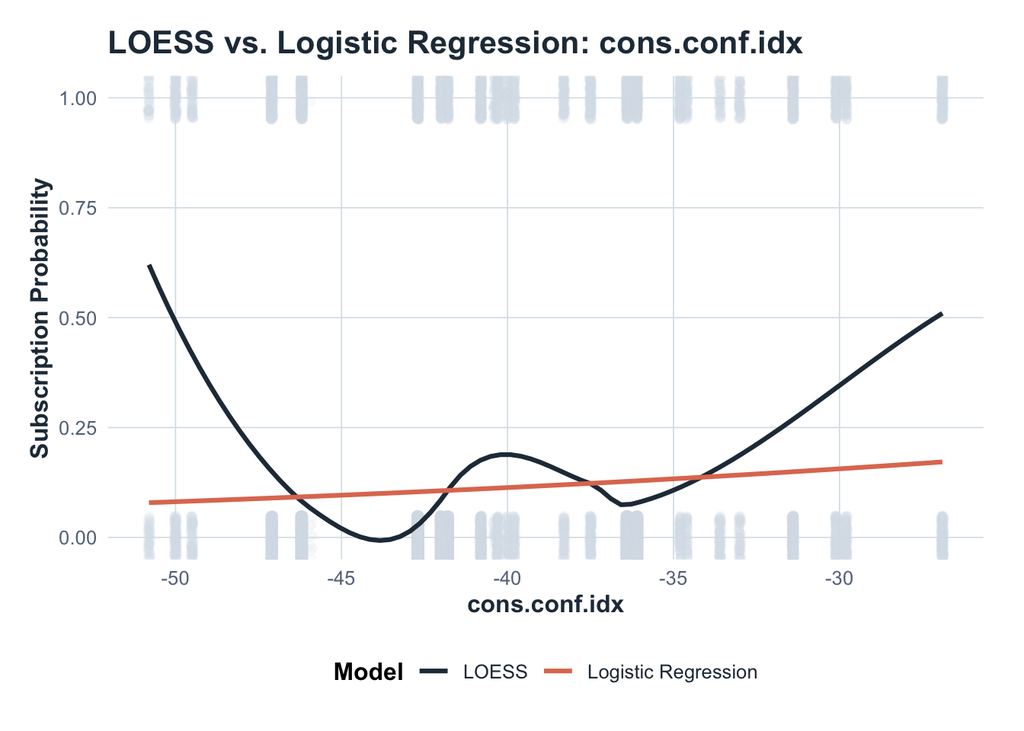

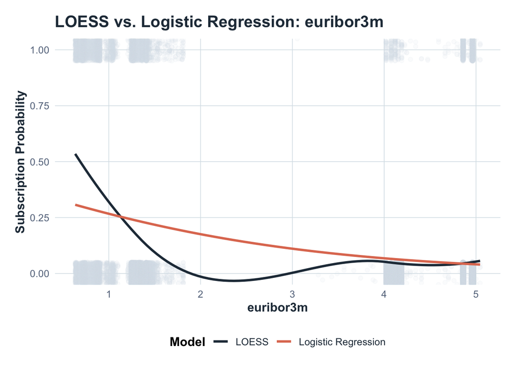

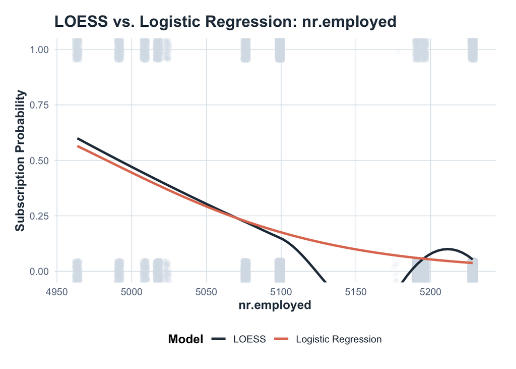

```r
for (var in num_vars) {

  p <- ggplot(bank_add,
              aes(x = .data[[var]], y = y_num)) +

    geom_jitter(
      height = 0.05,
      alpha = 0.1,
      color = bank_colors["light_blue"]
    ) +

    # LOESS curve
    geom_smooth(
      aes(color = "LOESS"),
      method = "loess",
      se = FALSE,
      span = 0.75
    ) +

    # Logistic regression curve
    geom_smooth(
      aes(color = "Logistic Regression"),
      method = "glm",
      method.args = list(family = "binomial"),
      se = FALSE
    ) +

    scale_color_manual(
      name = "Model",
      values = c(
        "LOESS" = unname(bank_colors["slate"]),
        "Logistic Regression" = unname(bank_colors["coral"])
      )
    ) +

    labs(
      title = paste("LOESS vs. Logistic Regression:", var),
      x = var,
      y = "Subscription Probability"
    ) +

    coord_cartesian(ylim = c(0, 1)) +
    theme_bank()

  print(p)
}
```

## Interactions Between Predictors

A correlation heatmap was used to assess pairwsie relationships between numerical predictors. The correlation heatmap shows strong positive correlations between `euribor3m` and `emp.var.rate`, as well as between `euribor3m` and `nr.employed`. This suggests that these predictors may be redundant and could potentially introduce multicollinearity in a predictive model.

We may find `poutcome` and `pdays` to have some multicollinearity later, but for EDA we can’t tell if this is a problem yet. Remember that `pdays` has a large number of 999 values, indicating that the client was not previously contacted. This may need to be treated as a categorical variable or imputed in some way.

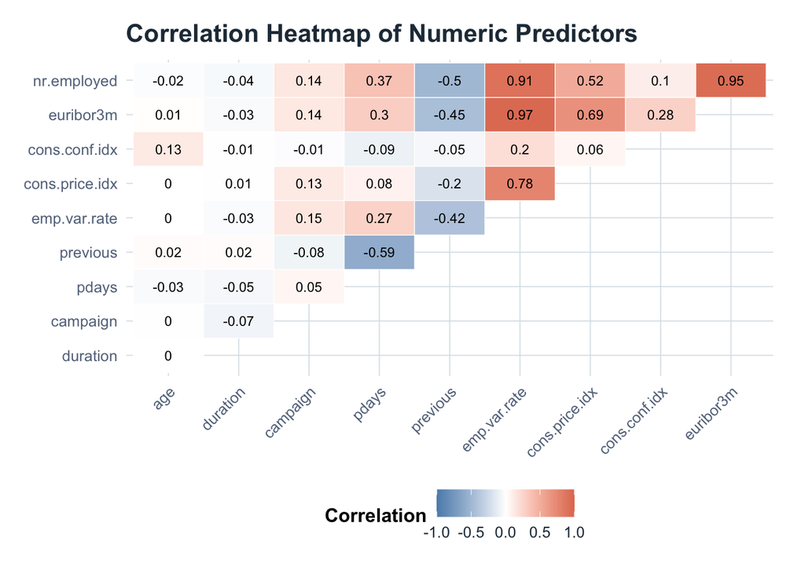

```r
cor_mat <- bank_add %>%
  select(all_of(num_vars)) %>%
  cor(use = "pairwise.complete.obs")

cor_long <- as.data.frame(as.table(cor_mat)) %>%
  rename(Var1 = Var1, Var2 = Var2, Correlation = Freq)

# Keep only upper triangle
cor_long$Var1 <- factor(cor_long$Var1, levels = colnames(cor_mat))
cor_long$Var2 <- factor(cor_long$Var2, levels = colnames(cor_mat))

cor_long <- cor_long %>%
  filter(as.numeric(Var1) < as.numeric(Var2))

ggplot(cor_long, aes(x = Var1, y = Var2, fill = Correlation)) +
  geom_tile(color = "white") +
  geom_text(aes(label = round(Correlation, 2)), size = 3) +
  scale_fill_gradient2(
    low = bank_colors["blue"],
    mid = "white",
    high = bank_colors["coral"],
    midpoint = 0,
    limits = c(-1, 1),
    name = "Correlation"
  ) +
  labs(
    title = "Correlation Heatmap of Numeric Predictors",
    x = NULL,
    y = NULL
  ) +
  theme_bank() +
  theme(
    axis.text.x = element_text(angle = 45, hjust = 1),
    panel.grid = element_blank()
  )
```

## Variance Inflation Factor (VIF)

Check VIF for a basic logistic regression model During multicollinearity diagnostics, the full logistic regression model showed aliasing (perfect multicollinearity) between the dummy variables representing unknown housing loan status and unknown personal loan status. These two indicator variables were identical across all observations used in the model, so they can be considered redundant.

```r
# Fit logistic regression with all candidate predictors:
# numeric y against everything but the original y
full_model <- glm(
  y_num ~ . - y,
  data = bank_add,
  family = binomial
)

# Check model
summary(full_model)
```

```
##
## Call:
## glm(formula = y_num ~ . - y, family = binomial, data = bank_add)
##
## Coefficients: (1 not defined because of singularities)
##                                Estimate Std. Error z value Pr(>|z|)
## (Intercept)                  -2.366e+02  3.831e+01  -6.176 6.56e-10 ***
## age                           1.966e-04  2.434e-03   0.081 0.935624
## jobblue-collar               -2.347e-01  7.988e-02  -2.939 0.003295 **
## jobentrepreneur              -1.780e-01  1.260e-01  -1.413 0.157566
## jobhousemaid                 -2.432e-02  1.478e-01  -0.165 0.869320
## jobmanagement                -5.614e-02  8.536e-02  -0.658 0.510710
## jobretired                    2.858e-01  1.071e-01   2.669 0.007606 **
## jobself-employed             -1.578e-01  1.178e-01  -1.340 0.180396
## jobservices                  -1.399e-01  8.610e-02  -1.624 0.104286
## jobstudent                    2.034e-01  1.115e-01   1.823 0.068230 .
## jobtechnician                -1.401e-02  7.113e-02  -0.197 0.843838
## jobunemployed                 2.116e-02  1.279e-01   0.165 0.868636
## jobunknown                   -7.049e-02  2.386e-01  -0.295 0.767646
## maritalmarried               -2.734e-03  6.854e-02  -0.040 0.968188
## maritalsingle                 5.591e-02  7.826e-02   0.714 0.474969
## maritalunknown                2.949e-02  4.167e-01   0.071 0.943587
## educationbasic.6y             1.226e-01  1.206e-01   1.017 0.309241
## educationbasic.9y            -9.772e-04  9.535e-02  -0.010 0.991823
## educationhigh.school          4.861e-02  9.210e-02   0.528 0.597676
## educationilliterate           1.067e+00  7.550e-01   1.413 0.157706
## educationprofessional.course  1.150e-01  1.015e-01   1.133 0.257261
## educationuniversity.degree    1.958e-01  9.220e-02   2.124 0.033667 *
## educationunknown              1.497e-01  1.195e-01   1.253 0.210204
## defaultunknown               -3.003e-01  6.740e-02  -4.456 8.36e-06 ***
## defaultyes                   -7.298e+00  1.134e+02  -0.064 0.948704
## housingunknown               -9.331e-02  1.398e-01  -0.668 0.504354
## housingyes                   -4.731e-03  4.135e-02  -0.114 0.908909
## loanunknown                          NA         NA      NA       NA
## loanyes                      -5.160e-02  5.747e-02  -0.898 0.369227
## contacttelephone             -6.460e-01  7.688e-02  -8.402  < 2e-16 ***
## monthaug                      8.653e-01  1.206e-01   7.174 7.26e-13 ***
## monthdec                      3.192e-01  2.093e-01   1.525 0.127236
## monthjul                      1.346e-01  9.630e-02   1.398 0.162205
## monthjun                     -5.243e-01  1.262e-01  -4.154 3.27e-05 ***
```

[output cut: 15 more lines]

```
## emp.var.rate                 -1.758e+00  1.420e-01 -12.380  < 2e-16 ***
## cons.price.idx                2.190e+00  2.524e-01   8.679  < 2e-16 ***
## cons.conf.idx                 2.069e-02  7.768e-03   2.664 0.007733 **
## euribor3m                     3.316e-01  1.300e-01   2.551 0.010737 *
## nr.employed                   5.413e-03  3.115e-03   1.738 0.082275 .
## ---
## Signif. codes:  0 '***' 0.001 '**' 0.01 '*' 0.05 '.' 0.1 ' ' 1
##
## (Dispersion parameter for binomial family taken to be 1)
##
##     Null deviance: 28999  on 41187  degrees of freedom
## Residual deviance: 17078  on 41135  degrees of freedom
## AIC: 17184
##
## Number of Fisher Scoring iterations: 10
```

```r
alias(full_model)$Complete
```

```
##             (Intercept) age jobblue-collar jobentrepreneur jobhousemaid
## loanunknown 0           0   0              0               0
##             jobmanagement jobretired jobself-employed jobservices jobstudent
## loanunknown 0             0          0                0           0
##             jobtechnician jobunemployed jobunknown maritalmarried maritalsingle
## loanunknown 0             0             0          0              0
##             maritalunknown educationbasic.6y educationbasic.9y
## loanunknown 0              0                 0
##             educationhigh.school educationilliterate
## loanunknown 0                    0
##             educationprofessional.course educationuniversity.degree
## loanunknown 0                            0
##             educationunknown defaultunknown defaultyes housingunknown
## loanunknown 0                0              0          1
##             housingyes loanyes contacttelephone monthaug monthdec monthjul
## loanunknown 0          0       0                0        0        0
##             monthjun monthmar monthmay monthnov monthoct monthsep
## loanunknown 0        0        0        0        0        0
##             day_of_weekmon day_of_weekthu day_of_weektue day_of_weekwed
## loanunknown 0              0              0              0
##             duration campaign pdays previous poutcomenonexistent
## loanunknown 0        0        0     0        0
##             poutcomesuccess emp.var.rate cons.price.idx cons.conf.idx euribor3m
## loanunknown 0               0            0              0             0
##             nr.employed
## loanunknown 0
```

```r
# loanunknown and housingunknown are aliased, so one of them should be removed from the model.
```

The model with loan removed shows some high VIF values, particularly for `nr.employed`,`euribor3m` and `emp.var.rate`, which are highly correlated. This suggests that these predictors may be redundant and could potentially introduce multicollinearity in a predictive model.

```r
full_model_no_loan <- glm(
  y_num ~ . - y - loan,
  data = bank_add,
  family = binomial
)

# summary(full_model_no_loan)

vif(full_model_no_loan)
```

```
##                      GVIF Df GVIF^(1/(2*Df))
## age              2.312897  1        1.520821
## job              5.832002 11        1.083453
## marital          1.465762  3        1.065804
## education        3.197933  7        1.086581
## default          1.142854  2        1.033946
## housing          1.014135  2        1.003515
## contact          2.318299  1        1.522596
## month           63.049855  9        1.258875
## day_of_week      1.066399  4        1.008068
## duration         1.243535  1        1.115139
## campaign         1.052431  1        1.025881
## pdays           10.992906  1        3.315555
## previous         4.474373  1        2.115271
## poutcome        24.228747  2        2.218619
## emp.var.rate   142.232401  1       11.926123
## cons.price.idx  68.108673  1        8.252798
## cons.conf.idx    5.333698  1        2.309480
## euribor3m      135.037594  1       11.620568
## nr.employed    172.009860  1       13.115253
```

## Polished VIF View

Note on df adjustment: For a categorical variable with k levels, the degrees of freedom (df) is k-1. The GVIF is adjusted by taking the (1/(2*df)) root to make it comparable across variables with different df. The VIF equivalent is then calculated as the square of the adjusted GVIF. This allows for a more interpretable measure of multicollinearity that accounts for the number of levels in categorical predictors.

```r
# library(tibble)

vif_results <- vif(full_model_no_loan)

if (is.matrix(vif_results)) {

  vif_table <- as.data.frame(vif_results) %>%
    rownames_to_column("Predictor") %>%
    transmute(
      Predictor,
      GVIF = GVIF,
      Df = Df,
      Adjusted_GVIF = GVIF^(1 / (2 * Df)),
      VIF_Equivalent = Adjusted_GVIF^2
    )

} else {

  vif_table <- tibble(
    Predictor = names(vif_results),
    GVIF = as.numeric(vif_results),
    Df = 1,
    Adjusted_GVIF = sqrt(GVIF),
    VIF_Equivalent = GVIF
  )

}

library(gt)

vif_table <- vif_table %>%
  mutate(
    Concern = case_when(
      VIF_Equivalent < 5 ~ "Low",
      VIF_Equivalent < 10 ~ "Moderate",
      TRUE ~ "High"
    )
  ) %>%
  arrange(desc(VIF_Equivalent))

vif_table %>%
  gt() %>%
  tab_header(
    title = "Multicollinearity Diagnostics",
    subtitle = "Full Logistic Regression Model"
  ) %>%
  cols_label(
    Predictor = "Predictor",
    GVIF = "GVIF",
    Df = "Df",
    Adjusted_GVIF = "Adjusted GVIF",
    VIF_Equivalent = "GVIF-Based VIF",
    Concern = "Concern Level"
  ) %>%
  fmt_number(
    columns = c(GVIF, Adjusted_GVIF, VIF_Equivalent),
    decimals = 2
  ) %>%
  data_color(
    columns = VIF_Equivalent,
    palette = c("#D9E2E8", "#E07A5F")
  ) %>%
  tab_options(
    table.font.size = 12,
    heading.title.font.size = 18,
    heading.subtitle.font.size = 12,
    column_labels.font.weight = "bold"
  )
```

Multicollinearity Diagnostics

Full Logistic Regression Model

| Predictor | GVIF | Df | Adjusted GVIF | GVIF-Based VIF | Concern Level |
| --- | --- | --- | --- | --- | --- |
| nr.employed | 172.01 | 1 | 13.12 | 172.01 | High |
| emp.var.rate | 142.23 | 1 | 11.93 | 142.23 | High |
| euribor3m | 135.04 | 1 | 11.62 | 135.04 | High |
| cons.price.idx | 68.11 | 1 | 8.25 | 68.11 | High |
| pdays | 10.99 | 1 | 3.32 | 10.99 | High |
| cons.conf.idx | 5.33 | 1 | 2.31 | 5.33 | Moderate |
| poutcome | 24.23 | 2 | 2.22 | 4.92 | Low |
| previous | 4.47 | 1 | 2.12 | 4.47 | Low |
| contact | 2.32 | 1 | 1.52 | 2.32 | Low |
| age | 2.31 | 1 | 1.52 | 2.31 | Low |
| month | 63.05 | 9 | 1.26 | 1.58 | Low |
| duration | 1.24 | 1 | 1.12 | 1.24 | Low |
| education | 3.20 | 7 | 1.09 | 1.18 | Low |
| job | 5.83 | 11 | 1.08 | 1.17 | Low |
| marital | 1.47 | 3 | 1.07 | 1.14 | Low |
| default | 1.14 | 2 | 1.03 | 1.07 | Low |
| campaign | 1.05 | 1 | 1.03 | 1.05 | Low |
| day_of_week | 1.07 | 4 | 1.01 | 1.02 | Low |
| housing | 1.01 | 2 | 1.00 | 1.01 | Low |